# K-neareast neighbours (KNN) classifier

## CV Studio and OpenCV

Created on JupyterLab

## KNN Image Classification with OpenCV and [Computer Vision Learning Studio (CV Studio)](https://vision.skills.network/?utm_medium=Exinfluencer&utm_source=Exinfluencer&utm_content=000026UJ&utm_term=10006555&utm_id=NA-SkillsNetwork-Channel-cvstudio-2021-01-01)

### Training Run: Train - KNN image classifier

Here, a K-Nearest Neighbours (k-NN), will be trained to classify dog/cat images. KNN learns from a labeled training set by taking in the training data along with its labels and learns to map the input to its desired output.

## Objectives

We will be classifying cat and dog images using `OpenCV` and [Computer Vision Learning Studio (CV Studio)](https://vision.skills.network/?utm_medium=Exinfluencer&utm_source=Exinfluencer&utm_content=000026UJ&utm_term=10006555&utm_id=NA-SkillsNetwork-Channel-cvstudio-2021-01-01). CV Studio is a fast, easy and collaborative open-source Computer Vision tool for teams and individuals. You can upload your datasets and label them yourself. If you created a separate folder for each image class, the tool will do the labeling for you.

- This tool contains the following sections:
  - Import Libraries
  - Load Images in Python
  - Plotting an Image
  - Gray Scale Images
  - k-NN for Image classification
  - Save your model to CVStudio

## Load Important Libraries

Libraries for data processing and visualization:

```python
import numpy as np
import pandas as pd
import matplotlib.pyplot as plt
from imutils import paths
import seaborn as sns
import random
import time
from datetime import datetime
```

Libraries for image pre-processing and classification:

```python
import cv2
from sklearn.model_selection import train_test_split
from sklearn.metrics import confusion_matrix
```

Libraries for OS and Cloud:

```python
import os
from skillsnetwork import cvstudio
```

## Download Your Images and Annotations

Now, let's initialize and download the images from the project you just created in CV Studio.

```python
# Initialize the CV Studio Client
cvstudioClient = cvstudio.CVStudio()

# Download All Images
cvstudioClient.downloadAll()
```

👈🏾 You can check the side panel to see if your images downloaded.

Get the annotations from the project you downloaded from CV Studio:

```python
annotations = cvstudioClient.get_annotations()
```

Let's view the format of the annotations we've just downloaded. The following code will display only the first 5 annotations. The annotations will come in a JSON file. What you can see is the image name as the key and `dog` as label object.

```python
first_five = {k: annotations["annotations"][k] for k in list(annotations["annotations"])[:5]}
first_five
```

```
{'006d07a5-4b27-43ab-a48c-2391c8c3b38b.jpg': [{'label': 'dog',
   'id': '17e654ad-467d-42eb-966f-9e295c7484b6'}],
 '06de30d2-c153-4640-98ab-be668280f807.jpg': [{'label': 'dog',
   'id': '8f026955-9ebc-45d6-9d07-cb3f4fa7de27'}],
 '072f1332-fd68-4361-b9aa-caef1cd24cea.jpg': [{'label': 'dog',
   'id': 'b2c1f09a-981d-4057-8ab8-37f89ef69d43'}],
 '0491be05-1d9e-4bcc-8c03-f5a363dc765f.jpg': [{'label': 'cat',
   'id': 'a8e96fec-517a-4055-843a-78dae2d35ef8'}],
 '0809601c-bbfd-4221-9950-ca2a681a2890.jpg': [{'label': 'cat',
   'id': 'ff5200e4-c79b-43f4-8a94-8d662abc64cc'}]}
```

# Load and Plot and Image

We will train and classify the images using the k-NN classifier using the `OpenCV` library. Before we start, let's get the images and take a look at some of them.

We will pick random images and take a look:

```python
random_filename = 'images/' + random.choice(list(annotations["annotations"].keys()))
```

Plot, read and show a random image using the `cv2.imread` and the `matplotlib` library.

We will also change the color space to `RGB` so we can plot it since `OpenCV` reads images as `BGR`. Early developers at `OpenCV` chose `BGR` color format because it was the format that was popular among camera manufacturers and software providers.

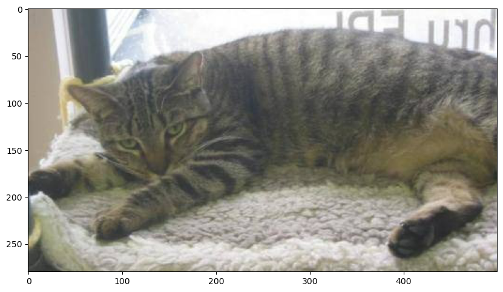

```python
sample_image = cv2.imread(random_filename)
## Convert to RGB
image = cv2.cvtColor(sample_image, cv2.COLOR_BGR2RGB)
## Now plot the image
plt.figure(figsize=(10,10))
plt.imshow(image, cmap = "gray")
plt.show()
```

To perform KNN on the dataset, we will need to process the data.

Convert image to grayscale - grayscale simplifies the algorithm and reduces computational requirements.

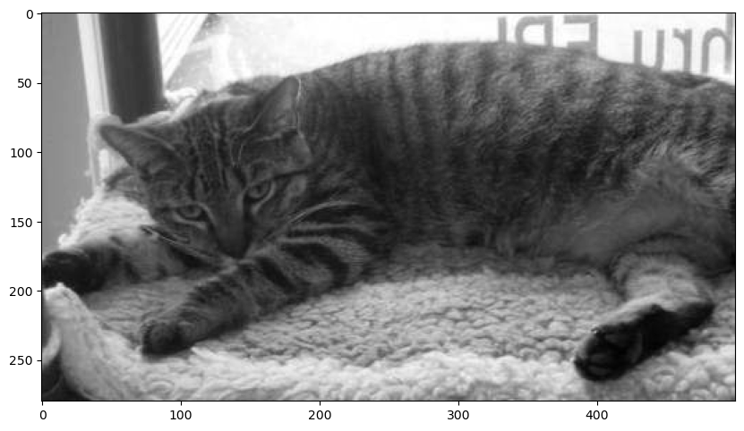

```python
sample_image = cv2.cvtColor(sample_image,cv2.COLOR_BGR2GRAY)
plt.figure(figsize=(10,10))
plt.imshow(sample_image, cmap = "gray")
plt.show()
```

Resize image - resizing image helps the algorithm train faster.

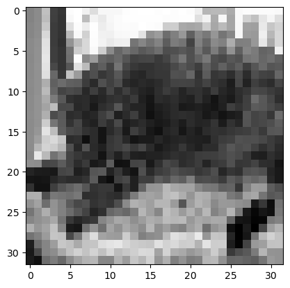

```python
sample_image = cv2.resize(sample_image, (32, 32))
plt.imshow(sample_image, cmap = "gray")
plt.show()
```

Flatten image - makes the image a numpy array for the algorithm to handle and recognize.

```python
pixels = sample_image.flatten()
pixels
```

```
array([151, 158, 202, ..., 140, 170, 164], dtype=uint8)
```

## Repeat the Process Above for All Images

We will now repeat the same process above to load and process all the images you’ve annotated and label each picture. KNN is supervised machine learning algorithm, therefore we have to explicitly create labels for the machine.

Depending on how much data you have, this will take a while to run...

```python
image_paths = list(paths.list_images('images'))
train_images = []
train_labels = []
class_object = annotations['labels']

# loop over the input images
for (i, image_path) in enumerate(image_paths):
    #read image
    image = cv2.imread(image_path)
    #make images gray
    image = cv2.cvtColor(image,cv2.COLOR_BGR2GRAY)
    #label image using the annotations
    label = class_object.index(annotations["annotations"][image_path[7:]][0]['label'])
    tmp_label = annotations["annotations"][image_path[7:]][0]['label']
    # resize image
    image = cv2.resize(image, (32, 32))
    # flatten the image
    pixels = image.flatten()
    #Append flattened image to
    train_images.append(pixels)
    train_labels.append(label)
    print('Loaded...', '\U0001F483', 'Image', str(i+1), 'is a', tmp_label)
```

```
Loaded... 💃 Image 1 is a dog
Loaded... 💃 Image 2 is a cat
Loaded... 💃 Image 3 is a dog
Loaded... 💃 Image 4 is a dog
Loaded... 💃 Image 5 is a cat
Loaded... 💃 Image 6 is a dog
Loaded... 💃 Image 7 is a cat
Loaded... 💃 Image 8 is a dog
Loaded... 💃 Image 9 is a cat
Loaded... 💃 Image 10 is a dog
Loaded... 💃 Image 11 is a dog
Loaded... 💃 Image 12 is a dog
Loaded... 💃 Image 13 is a dog
Loaded... 💃 Image 14 is a cat
Loaded... 💃 Image 15 is a cat
Loaded... 💃 Image 16 is a cat
Loaded... 💃 Image 17 is a cat
Loaded... 💃 Image 18 is a cat
Loaded... 💃 Image 19 is a dog
Loaded... 💃 Image 20 is a dog
Loaded... 💃 Image 21 is a dog
Loaded... 💃 Image 22 is a dog
Loaded... 💃 Image 23 is a cat
Loaded... 💃 Image 24 is a cat
Loaded... 💃 Image 25 is a cat
Loaded... 💃 Image 26 is a dog
Loaded... 💃 Image 27 is a dog
Loaded... 💃 Image 28 is a cat
Loaded... 💃 Image 29 is a cat
Loaded... 💃 Image 30 is a cat
Loaded... 💃 Image 31 is a cat
Loaded... 💃 Image 32 is a dog
Loaded... 💃 Image 33 is a dog
Loaded... 💃 Image 34 is a dog
Loaded... 💃 Image 35 is a dog
Loaded... 💃 Image 36 is a dog
Loaded... 💃 Image 37 is a dog
Loaded... 💃 Image 38 is a dog
Loaded... 💃 Image 39 is a dog
Loaded... 💃 Image 40 is a dog
```

[output cut: 145 more lines]

```
Loaded... 💃 Image 186 is a dog
Loaded... 💃 Image 187 is a cat
Loaded... 💃 Image 188 is a cat
Loaded... 💃 Image 189 is a dog
Loaded... 💃 Image 190 is a dog
Loaded... 💃 Image 191 is a dog
Loaded... 💃 Image 192 is a cat
Loaded... 💃 Image 193 is a dog
Loaded... 💃 Image 194 is a dog
Loaded... 💃 Image 195 is a cat
Loaded... 💃 Image 196 is a cat
Loaded... 💃 Image 197 is a dog
Loaded... 💃 Image 198 is a dog
Loaded... 💃 Image 199 is a dog
Loaded... 💃 Image 200 is a cat
```

Create an array of the `train_images` and `train_labels`. `OpenCV` only identifies arrays of type `float32` for the training samples and array of shape `(label size, 1)` for the training labels. We can do that by specifying `astype('float32')` on the numpy array of the training samples and convert the training labels to integers and `reshape` the array to `(label size, 1)`. When you print the `train_labels`, the array will look like this `[[1], [0], ..., [0]]`

```python
train_images = np.array(train_images).astype('float32')
train_labels = np.array(train_labels)
```

```python
train_labels = train_labels.astype(int)
train_labels = train_labels.reshape((train_labels.size,1))
#print(train_labels)
train_labels.shape
```

```
(200, 1)
```

```python
train_images.shape
```

```
(200, 1024)
```

Split data into training and test set with a test size of your choice:

```python
test_size = 0.2
train_samples, test_samples, train_labels, test_labels = train_test_split(
    train_images, train_labels, test_size=test_size, random_state=0)
```

To train the KNN model, we will use the `cv2.ml.KNearest_create()` from the `OpenCV` library. We need to define how many nearest neighbors will be used for classification as a hyper-parameter k. This parameter k can be toggled with/tuned in the training or model validation process. Fit the training and test images and get the accuracy score of the model.

We will try multiple values of `k` to find the optimal value for the dataset we have. `k` refers to the number of nearest neighbours to include in the majority of the voting process.

*Note:* Depending on how large your dataset is, it may take a few seconds to run.

```python
start_datetime = datetime.now()

knn = cv2.ml.KNearest_create()
knn.train(train_samples, cv2.ml.ROW_SAMPLE, train_labels)

## get different values of K
k_values = [1, 2, 3, 4, 5]
k_result = []
for k in k_values:
    ret,result,neighbours,dist = knn.findNearest(test_samples,k=k)
    k_result.append(result)
flattened = []
for res in k_result:
    flat_result = [item for sublist in res for item in sublist]
    flattened.append(flat_result)

end_datetime = datetime.now()
print('Training Duration: ' + str(end_datetime-start_datetime))
```

```
Training Duration: 0:00:00.028418
```

We will get the accuracy value for each value of `k` i.e., how many percent of the images were classified correctly? We will create a confusion matrix for a more comprehensive classification model evaluation.

```python
## create an empty list to save accuracy and the cofusion matrix
accuracy_res = []
con_matrix = []
## we will use a loop because we have multiple value of k
for k_res in k_result:
    label_names = [0, 1]
    cmx = confusion_matrix(test_labels, k_res, labels=label_names)
    con_matrix.append(cmx)
    ## get values for when we predict accurately
    matches = k_res==test_labels
    correct = np.count_nonzero(matches)
    ## calculate accuracy
    accuracy = correct*100.0/result.size
    accuracy_res.append(accuracy)
## stor accuracy for later when we create the graph
res_accuracy = {k_values[i]: accuracy_res[i] for i in range(len(k_values))}
list_res = sorted(res_accuracy.items())
```

**A Quick Guide to the Confusion Matrix**

A confusion matrix is a performance measurement for classification problem. It is a table with a combination of predicted and actual values. On the y-axis, we have the `True` label and on the x-axis we have the `Predicted` label. This example will focus on a binary classifier, i.e. a yes or no model.

|  | Predicted: NO | Predicted: YES |
| --- | --- | --- |
| True: NO | 30 | 30 |
| True: YES | 10 | 50 |

In this matrix, we can see that there are two classes. For example, if we were predicting if an image is a hotdog, "yes" will be a hotdog and "no" will be not a hotdog. We have 120 predictions and out of those times, the classifier predicted "yes" 80 times and "no" 40 times but really, there were 60 "yes"s and 60 "no"s.

When we talk about confusion matrix, we talk about a few terms:

- True Positive (TP): Our model predicted "yes", and it was actually "yes"
- True Negative (TN): Our model predicted "no", and it was actually "no"
- False Positive (FP): Our model predicted "yes", but it was actually "no"
- False Negative (FN): Our model predicted "no", but it was actually "yes"

Let's look at it in the context of our example:

|  | Predicted: NO | Predicted: YES |  |
| --- | --- | --- | --- |
| True: NO | TN = 30 | FP = 30 | 60 |
| True: YES | FN = 10 | TP = 50 | 60 |
|  | 40 | 80 |  |

**Accuracy** is the number the model got right over the total number of predictions. This is (TP+TN)/Total Number of Oredictions.

Now let's visualize the confusion matrix:

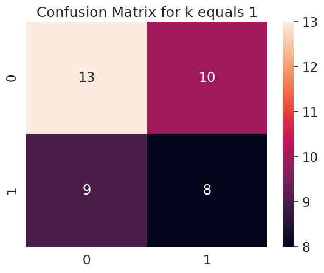

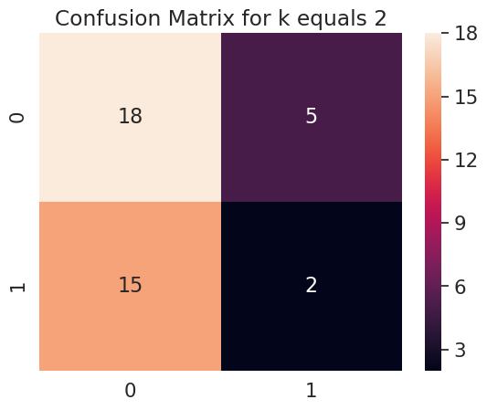

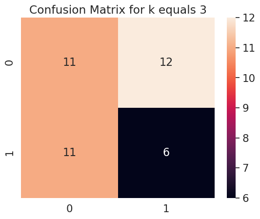

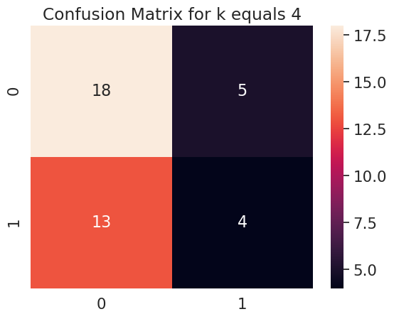

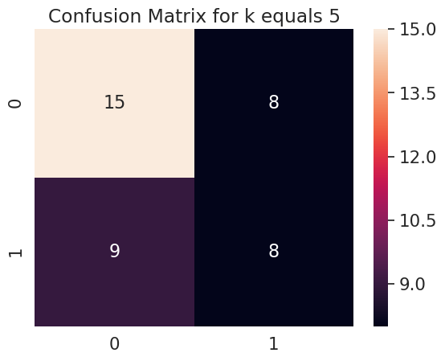

```python
t=0
## for each value of k we will create a confusion matrix
for array in con_matrix:
    df_cm = pd.DataFrame(array)
    sns.set(font_scale=1.4) # for label size
    sns.heatmap(df_cm, annot=True, annot_kws={"size": 16}, fmt = ".0f") # font size
    t += 1
    title = "Confusion Matrix for k equals " + str(t)
    plt.title(title)
    plt.show()
```

We will plot the accuracy to see which one is highest i.e., what percentage of images were classified correctly?

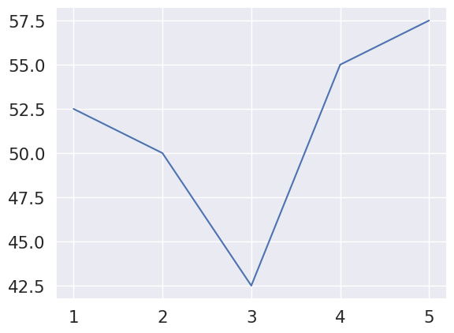

```python
## plot accuracy against
x, y = zip(*list_res)
plt.plot(x, y)
plt.show()
```

We will get the best value of `k` to train the model to test the model on our image:

```python
k_best = max(list_res,key=lambda item:item[1])[0]
k_best
```

```
5
```

## Let's Report Our Results Back to CV Studio

```python
parameters = {
    'k_best': k_best
}
result = cvstudioClient.report(started=start_datetime, completed=end_datetime, parameters=parameters, accuracy=list_res)

if result.ok:
    print('Congratulations your results have been reported back to CV Studio!')
```

Save the KNN model to a file:

```python
knn.save('knn_samples.yml')
```

👈🏾 Check that the `knn_samples.yml` was saved to your directory.

Now let's save the model back to CV Studio:

```python
result = cvstudioClient.uploadModel('knn_samples.yml', {'k_best': k_best})
```

```
File Uploaded
```

## Load the Saved KNN model to Classify Images

### Application: Use - KNN image classifier

The images will be uploaded and classified using the K-Nearest Neighbours (KNN) algorithm saved in the `train` run.

## Objectives

- This tool contains the following sections:
  - Load important libraries
  - Load your saved KNN model
  - Upload your image
  - Classify your image

## Load Important Libraries

Libraries for data processing and visualization:

```python
#import numpy as np
#import matplotlib.pyplot as plt
```

Libraries for image pre-processing and classification:

```python
#import cv2
```

Libraries for Computer Vision Studio:

```python
#from skillsnetwork import cvstudio
```

## Setup CV Studio Client, Get the Model and Annotations

```python
# Initialize the CV Studio Client
#cvstudioClient = cvstudio.CVStudio()
```

Get the annotations from the CV Studio project:

```python
#annotations = cvstudioClient.get_annotations()
```

Download the model (for k-NN this means samples and format):

```python
model_details = cvstudioClient.downloadModel()
```

Get k_best from model details (we reported this previously when training):

```python
k_best = model_details["k_best"]
print(k_best)
```

```
5
```

Load and re-train model:

```python
## get the model from the cv studio storage
fs = cv2.FileStorage(model_details['filename'], cv2.FILE_STORAGE_READ)
knn_yml = fs.getNode('opencv_ml_knn')

knn_format = knn_yml.getNode('format').real()
is_classifier = knn_yml.getNode('is_classifier').real()
## number of samples
default_k = knn_yml.getNode('default_k').real()
## sample arrays
samples = knn_yml.getNode('samples').mat()
## labels of sample
responses = knn_yml.getNode('responses').mat()
fs.release
knn = cv2.ml.KNearest_create()
knn.train(samples,cv2.ml.ROW_SAMPLE,responses)
```

```
True
```

## Test Our Model with an Uploaded Image

Upload an image that has not been used during training, and see if it will be correctly classified.

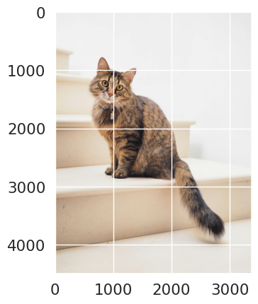

```python
my_image = cv2.imread("another_cat.jpg")
## let's see what the image looks like
image = cv2.cvtColor(my_image, cv2.COLOR_BGR2RGB)
plt.imshow(image)
plt.show()
```

Convert image to grayscale - grayscale simplifies the algorithm and reduces computational requirements.

```python
#make images gray
my_image = cv2.cvtColor(my_image,cv2.COLOR_BGR2GRAY)
```

Resize the image to reduce the size:

```python
my_image = cv2.resize(my_image, (32, 32))
```

Flatten the image into a numpy array:

```python
pixel_image = my_image.flatten()
pixel_image = np.array([pixel_image]).astype('float32')
```

Classify the image and print out the result of the model:

```python
ret,result,neighbours,dist = knn.findNearest(pixel_image,k=k_best)
print(neighbours)
print('Your image was classified as a ' + str(annotations['labels'][int(ret)]))
```

```
[[1. 0. 1. 0. 1.]]
Your image was classified as a cat
```

**When we print out the neigbours, it tells you the `k` closest classes and uses a majority voting process to pick what your image may be classified as.**

# Authors' rights

Machine Learning with Python course by IBM on Coursera: https://www.coursera.org/learn/machine-learning-with-python/

Completed and modified by Mathilde Marie Duville as part of the IBM Artificial Intelligence Engineering Professional Certificate and corresponding IBM badges. Please, follow the subsequent links to confirm the accreditation:

https://www.coursera.org/account/accomplishments/professional-cert/KSLW773DAATP?utm_source=link&utm_medium=certificate&utm_content=cert_image&utm_campaign=sharing_cta&utm_product=prof

https://www.credly.com/users/mathilde-marie-duville/badges

[Aije Egwaikhide](https://www.linkedin.com/in/aije-egwaikhide/?utm_medium=Exinfluencer&utm_source=Exinfluencer&utm_content=000026UJ&utm_term=10006555&utm_id=NA-SkillsNetwork-Channel-cvstudio-2021-01-01) is a Data Scientist at IBM who holds a degree in Economics and Statistics from the University of Manitoba and a Post-grad in Business Analytics from St. Lawrence College, Kingston. She is currently pursuing her Masters in Management Analytics at Queens University. She is part of the IBM Developer Skills Network group where she brings her real-world experience to the courses she creates.

## Training part

| Date (YYYY-MM-DD) | Version | Changed By | Change Description |
| --- | --- | --- | --- |
| 2021-05-25 | 1.2 | Kathy | Modified multiple areas |
| 2021-05-25 | 1.2 | Yasmine | Modified multiple areas |
| 2021-04-10 | 1.1 | Aije | Fixed grammatical errors |
| 2021-04-09 | 1.0 | Aije | Updated to new template |
| 2021-02-24 | 0.1 | Aije | Created original version of the lab |

## Testing part

| Date (YYYY-MM-DD) | Version | Changed By | Change Description |
| --- | --- | --- | --- |
| 2021-04-10 | 1.1 | Aije | Fixed grammatical errors and made comments headings |
| 2021-04-09 | 1.0 | Aije | Updated to new template |
| 2021-02-24 | 0.1 | Aije | Created original version of the lab |

Copyright © 2021 IBM Corporation. All rights reserved.